# Examples how to use `knitrContainer`

(knitrContainer v0.0.28)

Vilmantas Gegzna

2018-07-26

# 1 Introduction

## 1.1 About `knitrContainer`

`knitrContainer` is an [R](https://cran.r-project.org/) package designed to collect objects and print them in [`knitr`](http://yihui.name/knitr/) reports.

### 1.1.1 Why was it created?

Some objects such as `pander` tables and `plotly` plots, are not printed from inside loop in a `knitr` report file in a regular way.`knitrContainer` solves this problem by providing functions to get these objects printed and included in `HTML` files.

### 1.1.2 What king of objects can be collectd and printed with `knitrContainer`?

An object used by `knitrContainer` can be any object, that is includible in R list an that is printable, such as:

1. text;
2. objects printable with [`pander`](http://rapporter.github.io/pander/);
3. [`ggplot2`](http://ggplot2.org/), [`plotly`](https://plot.ly/r/) plots;
4. etc.

## 1.2 How to install the package?

From Git Hub repository:

```r
library(devtools)
install_github("GegznaV/knitrContainer")
```

## 1.3 How to use `knitrContainer`?

Only 4 things should be done for basic use of `knitrContainer` package :

1. Create a container(e.g. function `knitrContainer()`);
2. Add objects to the container (use `add_as_*` family functions, e.g. function `add_as_is()`);
3. In a R code chunk of [`knitr`](http://yihui.name/knitr/) report file set option `results` to `results='asis'`;
4. Print the objects appropriately: apply function `print_all()` in the chunk which has option `results='asis'`.

### 1.3.1 Example 1

```r
library(knitrContainer)
```

```r
container <- knitrContainer()
container <- add_as_text(container, "Text to be added.")
print_all(container)
```

### 1.3.2 Example 2

Example how to add objects using the operator `%<>%` from package [`magrittr`](https://github.com/smbache/magrittr#compound-assignment-pipe-operations):

```r
container %<>% add_as_text("Text added using `%<>%` operator.")
```

It is the same as:

```r
container <- add_as_text(container, "Text added using `<-` operator.")
```

Type the following code in R to learn more about operator `%<>%`:

```r
`?`(`%<>%`)
```

More detailed examples are presented in the following sections.

# 2 Functions for class `knitrContainer`

## 2.1 Load packages

```r
library(knitrContainer)

library(ggplot2)
library(plotly)
```

… and create necessary objects

```r
plotly_obj <- plot_ly(CO2, x = ~conc, y = ~uptake, type = "box", showlegend = FALSE)

ggplot_obj <- qplot(mpg, wt, data = mtcars, colour = cyl)
```

## 2.2 Create a `knitrContainer` object

```r
container <- knitrContainer()
class(container)
```

```
#> [1] "knitrContainer" "list"
```

```r
container
```

```
#> *** Empty container ***
```

## 2.3 Attach objects to the end of the container

```r
# Section headings
container <- add_as_heading1(container, "Plots")

# Add `plotly` objects as `htmlwidgets`
container <- add_as_heading2(container, "Add `plotly` as `plotly htmlwidget`")
container <- add_as_plotly_widget(container, plotly_obj)

# Add `ggplot` objects as plotly `htmlwidgets`
container <- add_as_heading2(container, "Add `ggplot` as `plotly htmlwidget`")
container <- add_as_plotly_widget(container, ggplotly(ggplot_obj))

# Add `ggplot` objects as `ggplot` objects
container <- add_as_heading2(container, "Add `ggplot` as-is")
container <- add_as_is(container, ggplot_obj)

# If `plotly` objects are aded as-is, they might not be plotted
container <- add_as_heading1(container, "Attention: Not Plotted")
container <- add_as_is(container, plotly_obj)
container <- add_as_text(container, paste("As you noticed, the last", "`plotly` object was not plotted as it was added with ",
    "`add_as_is()` and not with `add_as_plotly_widget()`"))

# --- Calculations ---
SUMMARY <- summary(mtcars[1:4])

# --- Add `pander` tables ---
container <- add_as_heading1(container, "Print SUMMARY as pander table and as text")

# Add objects, printed as `pander` tables
container <- add_as_heading2(container, "As pander table")
container <- add_as_pander(container, SUMMARY)

# Add as R output text
container <- add_as_heading2(container, "As Code/ Output Text")

container <- add_as_text(container, "Not highlighted")
container <- add_as_code(container, SUMMARY)

container <- add_as_text(container, "Highlighted as R code")
container <- add_as_code_r(container, SUMMARY)

container <- add_as_text(container, "Output with default `knitr` comments")
container <- add_as_output(container, SUMMARY)

container <- add_as_text(container, "Output with custom comments")
container <- add_as_output(container, SUMMARY, comment = "#$#>")

# Add as text = Add as one paragraph
container <- add_as_heading2(container, "As text/paragraph")
container <- add_as_text(container, SUMMARY)

# Add as-is
container <- add_as_heading2(container, "As is")
container <- add_as_is(container, SUMMARY)
```

# 3 Explore the container

Note, that functions `summary(container)` and `print(container)` do the same action: print summary of the object

```r
print(container)
```

```
#> ================================================================================
#>  *** knitr container ***
#>
#> Contains 26 object(s):
#>
#>    Added.as      Preview                   Size    Classes
#> 1  Heading       # Plots                   0.5 Kb  character
#> 2  Heading       ## Add `plotly` as `pl... 0.5 Kb  character
#> 3  Plotly widget                           33.8 Kb plotly, htmlwidget
#> 4  Heading       ## Add `ggplot` as `pl... 0.5 Kb  character
#> 5  Plotly widget                           71.2 Kb plotly, htmlwidget
#> 6  Heading       ## Add `ggplot` as-is     0.5 Kb  character
#> 7  As is                                   13.9 Kb gg, ggplot
#> 8  Heading       # Attention: Not Plotted  0.5 Kb  character
#> 9  As is                                   33.8 Kb plotly, htmlwidget
```

[output cut: 18 more lines]

```r
is.knitrContainer(container)
```

```
#> [1] TRUE
```

```r
is.knitrContainer(ggplot_obj)
```

```
#> [1] FALSE
```

```r
as.knitrContainer(ggplot_obj)
```

```
#> ================================================================================
#>  *** knitr container ***
#>
#> Contains 1 object(s):
#>
#>   Added.as Preview Size    Classes
#> 1 As is            13.9 Kb gg, ggplot
#> ================================================================================
```

```r
class(container)
```

```
#> [1] "knitrContainer" "list"
```

Merge several containers.

```r
Join(container, container) %>% length()
```

```
#> [1] 52
```

Convert (as is) to `knitrContainer` and merge.

```r
Join(container, ggplot_obj) %>% length()
```

```
#> [1] 27
```

As function uses method “as is” to convert to `knitrContainer`, `plotly` objects might not be printed from the container in some situations (e.g. from inside `for` loops using `knitr`).

```r
Join(ggplot_obj, plotly_obj)
```

```
#> ================================================================================
#>  *** knitr container ***
#>
#> Contains 2 object(s):
#>
#>   Added.as Preview Size    Classes
#> 1 As is            13.9 Kb gg, ggplot
#> 2 As is            33.8 Kb plotly, htmlwidget
#> ================================================================================
```

In these situations it is better to apply function `add_as_plotly_widget` first.

# 4 Print objects from the container (`print_all`)

In section **2** there we demonstrated how to create a `knitr_nontainer`. In this section we will demonstrate how to print all the objects from the container.

For this purpose a special function `print_all` was created. As we use `knitr` and `R MArkdown` we recommend to use separate R code chunk to apply the function. It is IMPORTANT to make sure that R chunk, in which `print_all()` is called, has option `results` set to `as is` (`{r, results = 'asis'}`). Otherwise incorrect results are expected.

The following text, section headings, figures etc. (except section “ADVANCED: …” and “Session information”) are printed from the container using the following syntax:

```r
print_all(container)
```

# 5 Plots

## 5.1 Add `plotly` as `plotly htmlwidget`

[interactive chart not shown]

## 5.2 Add `ggplot` as `plotly htmlwidget`

[interactive chart not shown]

## 5.3 Add `ggplot` as-is

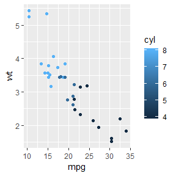

# 6 Attention: Not Plotted

[interactive chart not shown]

As you noticed, the last `plotly` object was not plotted as it was added with `add_as_is()` and not with `add_as_plotly_widget()`

# 7 Print SUMMARY as pander table and as text

## 7.1 As pander table

| mpg | cyl | disp | hp |
| --- | --- | --- | --- |
| Min. :10.40 | Min. :4.000 | Min. : 71.1 | Min. : 52.0 |
| 1st Qu.:15.43 | 1st Qu.:4.000 | 1st Qu.:120.8 | 1st Qu.: 96.5 |
| Median :19.20 | Median :6.000 | Median :196.3 | Median :123.0 |
| Mean :20.09 | Mean :6.188 | Mean :230.7 | Mean :146.7 |
| 3rd Qu.:22.80 | 3rd Qu.:8.000 | 3rd Qu.:326.0 | 3rd Qu.:180.0 |
| Max. :33.90 | Max. :8.000 | Max. :472.0 | Max. :335.0 |

## 7.2 As Code/ Output Text

Not highlighted

```
       mpg             cyl             disp             hp
  Min.   :10.40   Min.   :4.000   Min.   : 71.1   Min.   : 52.0
  1st Qu.:15.43   1st Qu.:4.000   1st Qu.:120.8   1st Qu.: 96.5
  Median :19.20   Median :6.000   Median :196.3   Median :123.0
  Mean   :20.09   Mean   :6.188   Mean   :230.7   Mean   :146.7
  3rd Qu.:22.80   3rd Qu.:8.000   3rd Qu.:326.0   3rd Qu.:180.0
  Max.   :33.90   Max.   :8.000   Max.   :472.0   Max.   :335.0
```

Highlighted as R code

```r
       mpg             cyl             disp             hp
  Min.   :10.40   Min.   :4.000   Min.   : 71.1   Min.   : 52.0
  1st Qu.:15.43   1st Qu.:4.000   1st Qu.:120.8   1st Qu.: 96.5
  Median :19.20   Median :6.000   Median :196.3   Median :123.0
  Mean   :20.09   Mean   :6.188   Mean   :230.7   Mean   :146.7
  3rd Qu.:22.80   3rd Qu.:8.000   3rd Qu.:326.0   3rd Qu.:180.0
  Max.   :33.90   Max.   :8.000   Max.   :472.0   Max.   :335.0
```

Output with default `knitr` comments

```
#>       mpg             cyl             disp             hp
#>  Min.   :10.40   Min.   :4.000   Min.   : 71.1   Min.   : 52.0
#>  1st Qu.:15.43   1st Qu.:4.000   1st Qu.:120.8   1st Qu.: 96.5
#>  Median :19.20   Median :6.000   Median :196.3   Median :123.0
#>  Mean   :20.09   Mean   :6.188   Mean   :230.7   Mean   :146.7
#>  3rd Qu.:22.80   3rd Qu.:8.000   3rd Qu.:326.0   3rd Qu.:180.0
#>  Max.   :33.90   Max.   :8.000   Max.   :472.0   Max.   :335.0
```

Output with custom comments

```
#$#>       mpg             cyl             disp             hp
#$#>  Min.   :10.40   Min.   :4.000   Min.   : 71.1   Min.   : 52.0
#$#>  1st Qu.:15.43   1st Qu.:4.000   1st Qu.:120.8   1st Qu.: 96.5
#$#>  Median :19.20   Median :6.000   Median :196.3   Median :123.0
#$#>  Mean   :20.09   Mean   :6.188   Mean   :230.7   Mean   :146.7
#$#>  3rd Qu.:22.80   3rd Qu.:8.000   3rd Qu.:326.0   3rd Qu.:180.0
#$#>  Max.   :33.90   Max.   :8.000   Max.   :472.0   Max.   :335.0
```

## 7.3 As text/paragraph

Min. :10.40 1st Qu.:15.43 Median :19.20 Mean :20.09 3rd Qu.:22.80 Max. :33.90 Min. :4.000 1st Qu.:4.000 Median :6.000 Mean :6.188 3rd Qu.:8.000 Max. :8.000 Min. : 71.1 1st Qu.:120.8 Median :196.3 Mean :230.7 3rd Qu.:326.0 Max. :472.0 Min. : 52.0 1st Qu.: 96.5 Median :123.0 Mean :146.7 3rd Qu.:180.0 Max. :335.0

## 7.4 As is

```
  mpg             cyl             disp             hp
```

Min. :10.40 Min. :4.000 Min. : 71.1 Min. : 52.0  
1st Qu.:15.43 1st Qu.:4.000 1st Qu.:120.8 1st Qu.: 96.5  
Median :19.20 Median :6.000 Median :196.3 Median :123.0  
Mean :20.09 Mean :6.188 Mean :230.7 Mean :146.7  
3rd Qu.:22.80 3rd Qu.:8.000 3rd Qu.:326.0 3rd Qu.:180.0  
Max. :33.90 Max. :8.000 Max. :472.0 Max. :335.0

# 8 ADVANCED: `add_as_data` and `add_as_cmd`

```r
container2 <- knitrContainer()
# Add as data and add as code to evaluate

# Add as data
container2 %<>% add_as_text("Add `mtcars` as data (it will not be printed) and rename it to 'cars_data'.")
container2 %<>% add_as_data(mtcars, give.name = "cars_data")

# Add as code to evaluate
container2 %<>% add_as_text(c("Use `add_as_cmd` to add unquoted code which manipulates the dataset ",
    "'cars_data', e.g. prints its variable names or plots it."))
container2 %<>% add_as_cmd(print(names(cars_data[1:3])))
container2 %<>% add_as_cmd(plot(cars_data[1:3]))
```

```r
print_all(container2)
```

Add `mtcars` as data (it will not be printed) and rename it to ‘cars_data’.

Use `add_as_cmd` to add unquoted code which manipulates the dataset ‘cars_data’, e.g. prints its variable names or plots it.

[1] “mpg” “cyl” “disp”

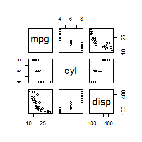

[session information not shown]